# Módulo 1

Introducción y Conceptos Básicos

Eloy Alvarado Narváez

eloy.alvarado@usm.cl

Universidad Técnica Federico Santa María

Esteban Salgado Valenzuela

Universidad Técnica Federico Santa María

13 de diciembre de 2024

# Introducción

## Introducción

### Aspectos del curso

- El curso *Seminario de Ingeniería Industrial* tiene como propósito entregar a los estudiantes una formación integral en conceptos y aplicaciones de la ciencia de datos, con un enfoque en su aplicabilidad en contextos industriales y de ingeniería. Durante el desarrollo del curso, se abordarán los fundamentos del aprendizaje estadístico y la evaluación de modelos, así como técnicas avanzadas de modelamiento y análisis de datos.

## Introducción

### Aspectos del curso

- Los contenidos se estructuran en módulos que incluyen:
  - Modelos de regresión: lineal, múltiple y polinomial.
  - Técnicas de clasificación: regresión logística, análisis discriminante y *naive Bayes*.
  - Métodos no supervisados como análisis de componentes principales y *clustering*.
  - Enfoques avanzados como *Support Vector Machines* y *Deep Learning*. En este último módulo, se estudiarán redes neuronales multicapa, convolucionales y recurrentes.

## Introducción

### Aspectos del curso

Este curso está basado en el libro

[figure not shown]

## Introducción

### Aspectos del curso

- El material del curso lo pueden encontrar en

https://github.com/ealvnrz/seminario_mii

[figure not shown]

## Introducción

### Aspectos del curso

La nota final ($NF$) de la asignatura será calculada de la siguiente manera:

$$NF = 0.4 * \overline{Q} + 0.6 * P,$$

donde $\overline{Q}$ es el promedio de quizzes y $P$ la nota del proyecto final del curso.

# Aprendizaje Estadístico

## Aprendizaje Estadístico

### ¿Qué es el aprendizaje estadístico?

- Campo de estudio que se centra en el desarrollo, análisis e implementación de métodos para comprender y predecir patrones en datos.
- Combina herramientas matemáticas y estadísticas con técnicas de computación para construir modelos que permiten analizar relaciones entre variables, identificar estructuras subyacentes y hacer predicciones basadas en datos observados.

## Aprendizaje Estadístico

### ¿Qué es el aprendizaje estadístico?: Tipos de problemas

- **Supervisado**
  - Se dispone de datos etiquetados $(X,Y)$, y el objetivo es aprender una relación $f(X)$ para predecir $Y$.
    - Predicción vs Inferencia.
    - *Regresión*: Output cuantitativo.
    - *Clasificación*: Output cualitativo.
- **No Supervisado**
  - No hay una variable de respuesta $Y$, y el objetivo es identificar patrones o estructuras en los datos $X$.
    - Entender la relación entre las variables

## Aprendizaje Estadístico

### Modelos supervisados

Veámoslo a través de un ejemplo …

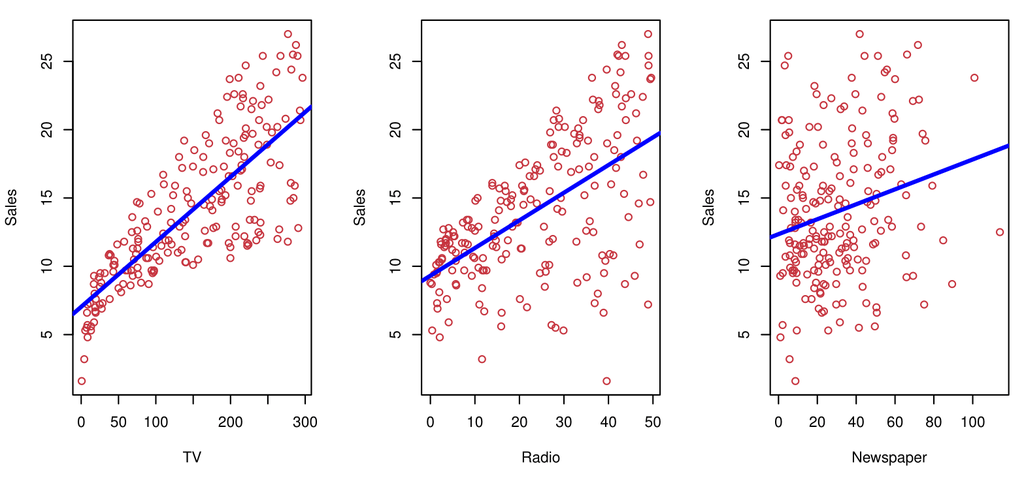

¿Podemos predecir las `ventas` utilizando estas tres variables?

¿Sería mejor utilizando un modelo conjunto? `venta` $\approx f$(`T`,`R`,`P`)

## Aprendizaje Estadístico

### Modelos supervisados

- Supongamos que observamos una respuesta cuantitativa $Y$ y $p$ predictores diferentes, $X_1,X_2,\ldots,X_p$.
- Asumimos que existe alguna relación entre
  $$Y \text{ y } X=(X_1,X_2,\ldots,X_p).$$
- Esta se puede expresar en la forma muy general:
  $$Y=f(X)+\varepsilon$$
  donde:
  - $f$ es una función fija pero desconocida de $X_1,\ldots,X_p$.
  - $\varepsilon$ es un término de error aleatorio, que es independiente de $X$ y tiene media cero.

## Aprendizaje Estadístico

### Modelos supervisados

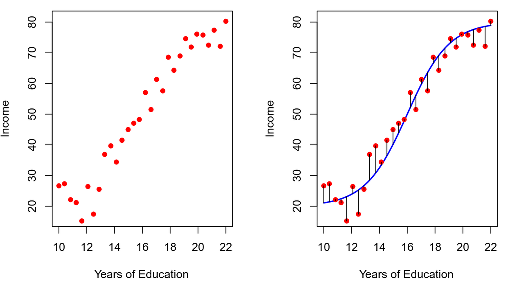

Ejemplo de la presencia de error aleatorio $\varepsilon$.

## Aprendizaje Estadístico

### Modelos supervisados: ¿Por qué estimar $f$?

- Predicción:
  - En muchas situaciones, un conjunto de inputs $X$ está fácilmente disponible, pero el output $Y$ no puede obtenerse fácilmente.
  - Dado que el término de error promedia a cero, podemos predecir $Y$ usando $\hat{Y}=\hat{f}(X).$
  - En este contexto, $\hat{f}$ a menudo se trata como una caja negra, en el sentido de que generalmente no importa la forma exacta de $\hat{f}$, siempre que proporcione predicciones precisas para $Y$.

## Aprendizaje Estadístico

### Modelos supervisados: ¿Por qué estimar $f$?

- Inferencia:
  - A menudo estamos interesados en comprender la asociación entre $Y$ y $X_1,\ldots,X_p$.
  - $\hat{f}$ no puede tratarse como una caja negra, porque necesitamos conocer su forma exacta.
  - Podría interesarnos responder las siguientes preguntas:
    - ¿Qué predictores están asociados con la respuesta?
    - ¿Cuál es la relación entre la respuesta y cada predictor?
    - ¿Puede la relación entre $Y$ y cada predictor resumirse adecuadamente usando una ecuación lineal, o es más complicada?

## Aprendizaje Estadístico

### Modelos supervisados: ¿Por qué estimar $f$?

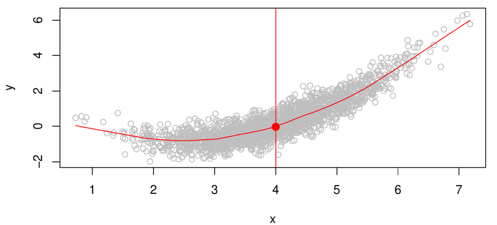

- La función de regresión $f(x) = \mathbb{E}(Y \mid X = x)$ es el predictor ideal u óptimo de $Y$ con respecto al error cuadrático medio de predicción.
- Esta es la función que minimiza $\mathbb{E}\left[(Y - g(X))^2 \mid X = x\right]$ para todas las funciones $g$ en todos los puntos $X = x$.
- Hay error reducible e irreducible:
  $$\mathbb{E}(Y-\hat{Y})^2 = \underbrace{[f(X)-\hat{f}(X)]^2}_{\text{Reducible}} + \underbrace{Var(\varepsilon)}_{Irreducible}$$

## Aprendizaje Estadístico

### Modelos supervisados: Paramétrico vs No paramétrico

- Paramétrico:
  - Se hace una suposición sobre la forma de $f$ (Ej: Lineal, polinomial).
  - Se usan los datos de entrenamiento para *entrenar* el modelo.
  - Si la forma del modelo elegida es muy distinta de $f$, el estimador puede ser malo.
  - Más interpretables (inferencia).

## Aprendizaje Estadístico

### Modelos supervisados: Paramétrico vs No paramétrico

- No paramétrico:
  - No se hacen suposiciones sobre la forma de $f$.
  - Se busca una estimación de $f$ que se acerque lo más posible a los datos de entrenaniento, sin ser demasiado abrupta o con demasiadas oscilaciones.
  - Potencial de ajustarse con precisión a una gama más amplia de posibles formas de $f$.
  - Se requiere un número mucho más grande de observaciones para obtener una estimación precisa de $f$.
  - No siempre es mejor para predicción.

## Aprendizaje Estadístico

### Modelos supervisados: Paramétrico vs No paramétrico

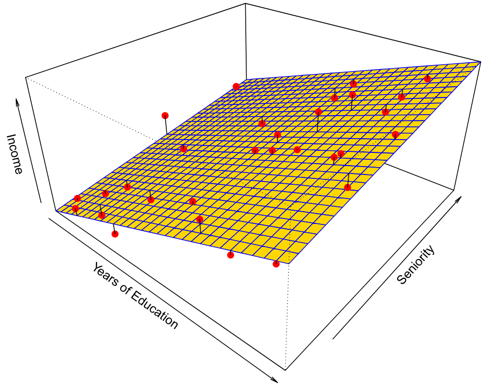

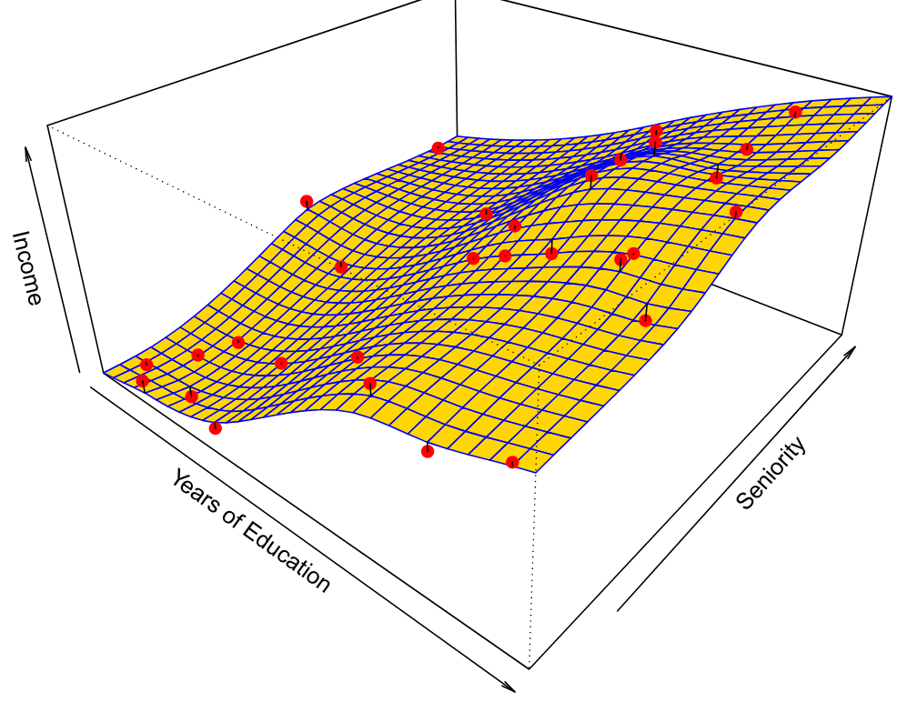

- *`Overfitting.`*

# Evaluación de modelos

## Evaluación de Modelos

### Medir calidad del estimador

- Error cuadrático medio: (Entrenamiento y Test)

$$MSE = \frac{1}{n}\sum\limits_{i=1}^n(y_i-\hat{f}(x_i))^2$$

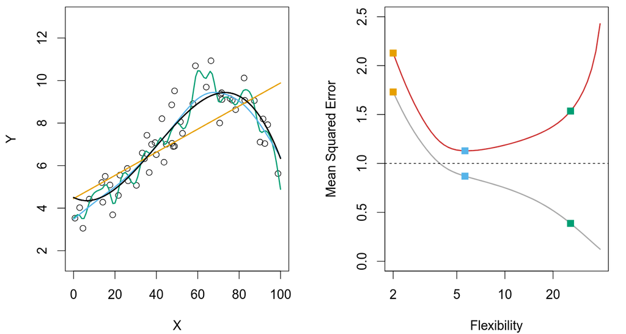

## Evaluación de Modelos

### Medir calidad del estimador

- Error cuadrático medio: (Test)

$$\mathbb{E}(y_0-\hat{f}(x_0))^2 = Var[\hat{f}(x_0)] + [Bias(\hat{f}(x_0))]^2 + Var(\varepsilon)$$

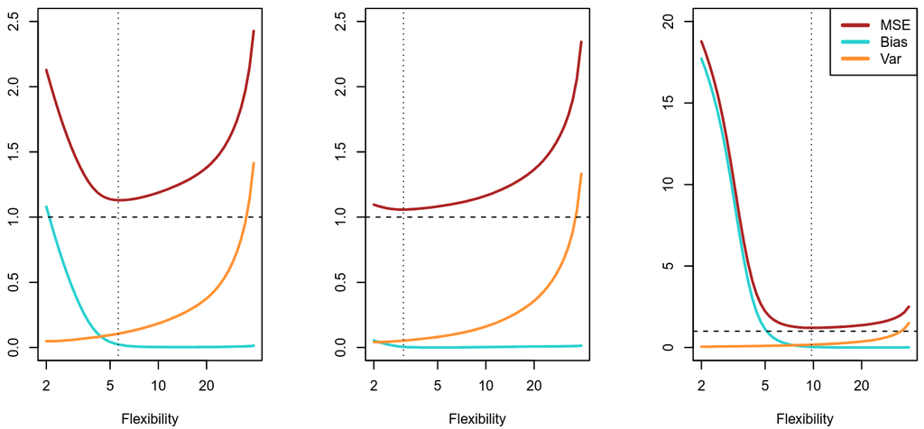

- Cambio en $\hat{f}$ si se estima usando otros datos.
- Error de aproximación por modelo más simple.

[figure not shown]